# Cleaning Script for Study Visit Dates

John Curtin with updates by Hannah Moshontz (Updated by Kendra Wyant 3-10-21)

2021-03-20

### Notes

Purpose: aggregates, cleans, and tidys visit date files

Guidelines for visit dates:

- Visit dates will only include completed visits. Participants who left before completing their visit (i.e., no longer eligible or discontinued) have a visit marked as NA.
- Followup visits completed at home have a visit date if they completed the survey - at home visits are documented in this script and in the raw_notes file.
- The number of subids in the cleaned visit dates file is equal to the number of participants who completed the screen visit (n = 207). As such not everyone will have a study start and end date.
- Study start dates are the day after intake, unless otherwise noted.
- End study dates are roughly 90 days after study start. For participants who discontinue the study with a clear date noted, end date will be discontinuation date. For participants who passively discontinue, end study date will be amended to their last EMA or last completed study visit (whichever is later). An exception to this rule will be if it appears that the last EMA was sporadic and not indicative that they were consistently providing data up until this EMA. In these situations we will evaluate on a case to case basis what the correct end date should be.  
  **Note: Last EMA is determined by cleaned EMA file - due to how critical it is that the end date is correct we decided to use clean data instead of our usual restriction to raw data for cleaning**
- All imputed end dates are documented in end date EDA.

Inputs:

Path raw

- [subid]_VisitDates.xlsx
- screen.csv
- intake.csv
- followup_12.csv
- followup_3.csv
- raw_notes.csv

Path log

- log_visit_dates.csv

Path data

- session_screen.csv
- session_intake.csv
- session_followup12.csv
- session_followup3.csv
- ema_later.csv
- ema_morning.csv

Outputs:

Path data

- visit_dates.csv

### Setup

Packages and Source

```r
library(tidyverse)
library(janitor)
library(readxl)  # read excel file
library(naniar) # missing data
library(lubridate)
library(kableExtra)
```

Paths

```r
path_raw <- "raw_data"
path_log <- "analysis/shared/notes"
path_data <- "analysis/shared/data"
```

### Open and merge files

```r
read_file <- function(filepath) {

  subid <- str_extract(filepath, "\\d\\d\\d")

  data <- read_excel(filepath,
                     na = c('NA', '', NULL),
                     col_types = "date") %>%
    mutate(subid = as.numeric(subid)) %>%
    relocate(subid)

  return(data)
}

visit_dates <- list.files(file.path(path_raw),
           pattern = "VisitDates.xlsx", #this accommodates folders without visit dates
           recursive = TRUE,
           full.names = TRUE) %>%

  map_df(read_file) %>%
  mutate(across((-subid), date)) #dropping the time component
```

### Clean by log

Functions

```r
# function to add any subids in log not already in visit dates
add_subs <- function(dates, log){
  log_subids <- tibble(subid = unique(log$subid))
  new_subids <- log_subids %>% filter(!subid %in% dates$subid) %>% unlist(use.names = FALSE)

  for (i in 1:length(new_subids)) {
     dates <- dates %>%
        add_row(subid = new_subids[i])
  }
  return(dates)
}

# function to clean log
clean_log <- function(..., log){
  data_row <- tibble(...) # (the tibble is turned into a list by pmap)
  # convert list element to a tibble of one row
  log_subid <- log %>% #filter to just the log entries for that subject
    filter(subid == data_row$subid)

  if (nrow(log_subid) >= 1) {

    for (i in 1:nrow(log_subid)) {

     data_row[[pluck(log_subid, "var_name", i)]] <- pluck(log_subid, "new_value", i)
    }
  }
  return(data_row)
}
```

Clean visit dates

```r
log <- read_csv(file.path(path_log, "log_visit_dates.csv"), col_types = cols())

visit_dates <- add_subs(visit_dates, log)

visit_dates <- visit_dates %>%
  pmap_dfr(clean_log, log = log) %>%
  clean_names("snake") %>%
  rename(followup_1 = followup1, followup_2 = followup2) %>%
  glimpse()
```

```
## Rows: 207
## Columns: 8
## $ subid       <dbl> 1, 2, 3, 5, 6, 7, 9, 10, 11, 15, 16, 17, 18, 19, 20, 21...
## $ screen      <date> 2017-02-15, 2017-02-17, 2017-03-07, 2017-05-31, 2017-0...
## $ intake      <date> 2017-03-01, 2017-03-23, 2017-03-21, 2017-06-19, 2017-0...
## $ start_study <date> 2017-03-02, 2017-03-24, 2017-03-22, 2017-06-20, 2017-0...
## $ followup_1  <date> 2017-03-31, 2017-04-21, 2017-04-26, 2017-07-19, 2017-0...
## $ followup_2  <date> 2017-05-01, 2017-05-22, 2017-05-24, 2017-08-21, 2017-0...
## $ end_study   <date> 2017-05-31, 2017-06-16, 2017-06-20, 2017-09-18, 2017-0...
## $ final_visit <date> 2017-06-05, 2017-06-16, 2017-06-21, 2017-09-22, 2017-0...
```

## EDA for cleaned visit dates

The original visit date will be compared to the raw uncleaned survey end date. Where there are discrepancies we will look at the cleaned session form dates and notes for a resolution.

Note KW: not using raw session form dates since these files are not in a single aggregate file. Due to the data having already been cleaned, the session forms will be used as a note file to help us resolve discrepancies whereas the raw survey dates will be used directly in the EDA to locate errors and discrepancies.

Note KW: EMA data will also be brought in later to perform EDA on start and end study dates.

### Import supporting data

Will compare visit dates against raw uncleaned survey end dates

```r
screen <- read_csv(file.path(path_raw, 'qualtrics/screen.csv'), col_types = cols())
intake <- read_csv(file.path(path_raw, 'qualtrics/intake.csv'), col_types = cols())
screen <- read_csv(file.path(path_raw, 'qualtrics/screen.csv'), col_types = cols())
followup_12 <- read_csv(file.path(path_raw, 'qualtrics/followup_12.csv'), col_types = cols())
followup_3 <- read_csv(file.path(path_raw, 'qualtrics/followup_3.csv'), col_types = cols())
```

cleaned session form end dates, raw_notes, survey logs, and google calendar will provide info to resolve discrepancies

```r
session_screen <- read_csv(file.path(path_data, 'session_screen.csv'), col_types = cols())
session_intake <- read_csv(file.path(path_data, 'session_intake.csv'), col_types = cols())
session_screen <- read_csv(file.path(path_data, 'session_screen.csv'), col_types = cols())
session_followup_12 <- read_csv(file.path(path_data, 'session_followup_12.csv'), col_types = cols())
session_followup_3 <- read_csv(file.path(path_data, 'session_followup_3.csv'), col_types = cols())

notes <- read_csv("./raw_data/raw_notes.csv", col_types = cols())
cal <- ical::ical_parse_df(file.path(path_raw, "gcal_risk.ics"))

log_screen <- read_csv(file.path(path_log, "log_screen.csv"), col_types = cols())
log_intake <- read_csv(file.path(path_log, "log_intake.csv"), col_types = cols())
log_followup_12 <- read_csv(file.path(path_log, "log_followup_12.csv"), col_types = cols())
log_followup_3 <- read_csv(file.path(path_log, "log_followup_3.csv"), col_types = cols())
```

load google calendar function

```r
show_calendar_events <- function(focal_date){
  cal %>%
  arrange(start) %>%
  filter(month(start) == month(focal_date),
         year(start) == year(focal_date),
         day(start) == day(focal_date)) %>%
  select(-uid, -status) %>%
  kable(caption = "All calendar events on the day of the session") %>%
  kable_styling()
}
```

### Glimpse subids and missing data

```r
dup_subs <- visit_dates %>%
  count(subid) %>%
  filter(n > 1)
```

207 subids with visit dates.  
0 subids with more than one visit dates row.

```r
naniar::miss_var_summary(visit_dates)
```

```
## # A tibble: 8 x 3
##   variable    n_miss pct_miss
##   <chr>        <int>    <dbl>
## 1 final_visit     74     35.7
## 2 followup_2      68     32.9
## 3 followup_1      53     25.6
## 4 intake          37     17.9
## 5 start_study     37     17.9
## 6 end_study       37     17.9
## 7 subid            0      0
## 8 screen           0      0
```

Note KW: 37 missing start, end, and intake dates are all confirmed to be subids who completed screen but did not complete intake - this could be due to screening ineligible, not showing up to intake, or leaving intake before completing visit.

Check date ranges for each variable  
No odd dates stand out

```r
visit_dates %>%
  summarise(across(screen:final_visit, min, na.rm = TRUE)) %>%
            pivot_longer(cols = everything(), names_to = "visit", values_to = "min") %>%
  left_join(visit_dates %>%
            summarise(across(screen:final_visit, max, na.rm = TRUE)) %>%
            pivot_longer(cols = everything(), names_to = "visit", values_to = "max"), by = "visit")
```

```
## # A tibble: 7 x 3
##   visit       min        max
##   <chr>       <date>     <date>
## 1 screen      2017-02-15 2019-09-19
## 2 intake      2017-03-01 2019-09-06
## 3 start_study 2017-03-02 2019-09-07
## 4 followup_1  2017-03-31 2019-10-03
## 5 followup_2  2017-05-01 2019-11-07
## 6 end_study   2017-05-31 2019-12-04
## 7 final_visit 2017-06-05 2019-12-05
```

Note: For some participants, the latest final visit happened after the latest end study, which is not an error. People sometimes came in for their final session after they were off study. We use observations within the on-study period.

### Screen

#### Check subids with screen visit

Using completed screen surveys as starting sample for who should be included in visit_dates

```r
screen <- screen %>%
  mutate(EndDate = as_date(EndDate, tz = "America/Chicago")) %>%
  select(subid = SubID,
         survey_date = EndDate,
         response_id = ResponseID,
         finished = Finished) %>%
  glimpse()
```

```
## Rows: 208
## Columns: 4
## $ subid       <dbl> 1, 2, 3, 5, 6, 7, 8, 8, 11, 12, 13, 14, 15, 16, 17, 9, ...
## $ survey_date <date> 2017-02-15, 2017-02-17, 2017-03-07, 2017-05-31, 2017-0...
## $ response_id <chr> "R_6PxeckNv16lrXFP", "R_WBuA18trr74hZWV", "R_AMBVeDRBZh...
## $ finished    <dbl> 1, 1, 1, 1, 1, 1, 1, 1, 1, 1, 1, 1, 1, 1, 1, 1, 1, 1, 1...
```

208 subids with screen surveys.  
2 incomplete surveys.

incomplete surveys

```r
(screen_incomp <- screen %>%
  filter(finished != 1))
```

```
## # A tibble: 2 x 4
##   subid survey_date response_id       finished
##   <dbl> <date>      <chr>                <dbl>
## 1    66 2018-05-10  R_R3lSsXdXoYd0hdD        0
## 2   155 2018-10-26  R_3j9vNPmoZjEumL0        0
```

subid 155 did not complete screen  
subid 66 DID complete screen

```r
notes %>%
  select(subid, notes_general) %>%
  filter(subid %in% screen_incomp$subid) %>%
  kbl() %>%
  kable_styling()
```

| subid | notes_general |
| --- | --- |
| 66 | RA does not trust the contacts data given at FU #2 and FU#3. The participant seemed to be in a rush and marked several contacts irrelevant/spam and neglected to answer the contact follow-up questions … |
| 155 | Partial response to ID Screen Battery. Responses to the survey seemed questionable as to whether the participant was being honest and reading the questions as they responded. The participant took appr… |

```r
log_screen %>%
  filter(subid == 66) %>%
  kbl() %>%
  kable_styling()
```

| subid | response_id | log_action | var_name | old_value | new_value | source | notes |
| --- | --- | --- | --- | --- | --- | --- | --- |
| 66 | R_R3lSsXdXoYd0hdD | recode_one | Finished | 0 | 1 | KW | Survey is complete - incorrectly marked as incomplete. Participant goes on to enroll in study. |

Visit dates should have 207 subids  
subids in visit dates but not in screen

```r
screen_subs <- screen %>%
  filter(subid != 155) %>%
  select(subid) %>%
  unlist(use.names = FALSE)

visit_dates %>%
  filter(!subid %in% screen_subs)
```

```
## # A tibble: 5 x 8
##   subid screen     intake     start_study followup_1 followup_2 end_study
##   <dbl> <date>     <date>     <date>      <date>     <date>     <date>
## 1    10 2017-06-29 2017-07-13 2017-07-14  2017-08-14 2017-09-19 2017-10-12
## 2    23 2017-10-17 2017-11-08 2017-11-09  2017-12-12 2018-01-10 2018-02-07
## 3    61 2018-03-27 2018-05-02 2018-05-03  NA         NA         2018-06-04
## 4    78 2018-06-21 2018-07-02 2018-07-03  2018-08-01 2018-09-05 2018-09-05
## 5   150 2018-10-15 2018-10-29 2018-10-30  2018-12-03 2019-01-07 2019-01-27
## # ... with 1 more variable: final_visit <date>
```

Check for subid errors in log

```r
log_screen %>%
  filter(var_name == "subid") %>%
  kbl() %>%
  kable_styling()
```

| subid | response_id | log_action | var_name | old_value | new_value | source | notes |
| --- | --- | --- | --- | --- | --- | --- | --- |
| 8 | R_3qIO5N1X1tyCWeN | recode_one | subid | 8 | 10 | HM | Subject 10 was missing a screen and subject 8 had two on different dates. On the focal date, there was one scheduled screen for a participant identified as #20312. The screen session form for that day… |
| 22 | R_3p4naYVKxD8b31H | recode_one | subid | 22 | 23 | HM | There are two screen batteries dated October 17, 2017 with the SUBID 022. The RA names and times on session forms support this change. There is only one session screen form for the focal day, and it’s… |
| 149 | R_3mkH0rLyisMbJVT | recode_one | subid | 149 | 150 | HM | Subject 149 has two screens on different days and subject 150 is missing one. Same for the sesion forms. The calendar indicates that subject 150 was in on the focal date. In addition, with these corre… |
| 55 | R_2xzxfV4i1kyOqaU | recode_one | subid | 55 | 61 | HM | A participant was enrolled at two different times with different subids (first 55, then 61). The second time they were enrolled, they participated as usual except that they did not complete a new scre… |
| 79 | R_RCtBJYBoTE7vD2h | recode_one | subid | 79 | 78 | HM | There are 2 total screen surveys subject 79 and zero for 78. The only screen scheudled on the focal day was for 78. There is no screen for 78 on any other day. An RA marked both the session form and t… |

Log explains all discrepancies  
Temp recode subids survey tibble for date comparison

```r
screen <- screen %>%
  mutate(subid = case_when(response_id == "R_3qIO5N1X1tyCWeN" ~ 10,
                           response_id == "R_3p4naYVKxD8b31H" ~ 23,
                           response_id == "R_3mkH0rLyisMbJVT" ~ 150,
                           response_id == "R_2xzxfV4i1kyOqaU" ~ 61,
                           response_id == "R_RCtBJYBoTE7vD2h" ~ 78,
                           TRUE ~ subid))

screen_subs <- screen %>%
  filter(subid != 155) %>%
  select(subid) %>%
  unlist(use.names = FALSE)

visit_dates %>%
  filter(!subid %in% screen_subs)
```

```
## # A tibble: 0 x 8
## # ... with 8 variables: subid <dbl>, screen <date>, intake <date>,
## #   start_study <date>, followup_1 <date>, followup_2 <date>, end_study <date>,
## #   final_visit <date>
```

subids in screen but not in visit dates

```r
screen %>%
  filter(subid != 155) %>%
  filter(!subid %in% visit_dates$subid)
```

```
## # A tibble: 0 x 4
## # ... with 4 variables: subid <dbl>, survey_date <date>, response_id <chr>,
## #   finished <dbl>
```

All subids accounted for in visit dates

#### Check visit dates

Compare visit date and survey date  
Check for date discrepancies between visit and survey date

```r
(screen_discrep <- visit_dates %>%
  select(subid, visit_date = screen) %>%
  left_join(screen %>% select(subid, survey_date, response_id), by = "subid") %>%
  filter(visit_date != survey_date))
```

```
## # A tibble: 2 x 4
##   subid visit_date survey_date response_id
##   <dbl> <date>     <date>      <chr>
## 1     9 2017-06-21 2017-10-05  R_xyFFfXh1up0Fk5P
## 2   187 2019-02-11 2019-02-26  R_3Dpyy1Hk9hsdrCv
```

2 date discrepancies for screen

Other sources of date info:  
Notes on subids

```r
notes %>%
  filter(subid %in% screen_discrep$subid) %>%
  select(subid, notes_general) %>%
  kbl() %>%
  kable_styling()
```

| subid | notes_general |
| --- | --- |
| 9 | R was not used to obtain unreported contacts or locations while the participant was on-study; Participant was in the hospital for several days at the end of September and therefore has lower complianc… |
| 187 | NA |

Log entries show survey date was changed to match screen visit date.

```r
log_screen %>%
  filter(var_name == "StartDate" | var_name == "EndDate") %>%
  kbl() %>%
  kable_styling()
```

| subid | response_id | log_action | var_name | old_value | new_value | source | notes |
| --- | --- | --- | --- | --- | --- | --- | --- |
| 9 | R_xyFFfXh1up0Fk5P | recode_one | StartDate | 2017-10-05 21:34:36 | 2017-06-21 16:27:21 | KW | The screen for subject 009 incorrectly had a subID ‘JohnsonHurwitz;Nagler’ John Retook the response to correct this but it changed the UTC time stamp. The UTC time stamp for 009 should be 1498062441 -… |
| 9 | R_xyFFfXh1up0Fk5P | recode_one | EndDate | 2017-10-05 21:36:23 | 2017-06-21 16:27:21 | KW | The screen for subject 009 incorrectly had a subID ‘JohnsonHurwitz;Nagler’ John Retook the response to correct this but it changed the UTC time stamp. The UTC time stamp for 009 should be 1498062441 -… |
| 187 | R_3Dpyy1Hk9hsdrCv | recode_one | StartDate | 2019-02-26 19:55:25 | 2019-02-11 18:01:00 | KW | A screen was completed on 2/11/2019 with participant #187. The subId and study name column were switched. In error, the screen was retaken to fix this mistake and changed the screen completion date to… |
| 187 | R_3Dpyy1Hk9hsdrCv | recode_one | EndDate | 2019-02-26 19:56:51 | 2019-02-11 18:01:00 | KW | A screen was completed on 2/11/2019 with participant #187. The subId and study name column were switched. In error, the screen was retaken to fix this mistake and changed the screen completion date to… |

Log entries explain survey date was incorrect for subids 9 and 187 and that they have correct visit dates.

Session form dates confirm visit date as well

```r
session_screen %>%
  filter(subid %in% screen_discrep$subid) %>%
  mutate(session_date = as_date(end_date, tz = "America/Chicago")) %>%
  select(subid, session_date) %>%
  left_join(screen_discrep, by = "subid")
```

```
## # A tibble: 2 x 5
##   subid session_date visit_date survey_date response_id
##   <dbl> <date>       <date>     <date>      <chr>
## 1     9 2017-06-21   2017-06-21 2017-10-05  R_xyFFfXh1up0Fk5P
## 2   187 2019-02-11   2019-02-11 2019-02-26  R_3Dpyy1Hk9hsdrCv
```

### Intake

#### Check subids with intake visit

```r
intake <- intake %>%
  mutate(EndDate = as_date(EndDate, tz = "America/Chicago")) %>%
  select(subid = SubID,
         survey_date = EndDate,
         response_id = ResponseID,
         finished = Finished) %>%
  glimpse()
```

```
## Rows: 172
## Columns: 4
## $ subid       <dbl> 1, 3, 2, 6, 7, 5, 8, 9, 10, 11, 15, 16, 17, 18, 21, 20,...
## $ survey_date <date> 2017-02-23, 2017-03-21, 2017-03-23, 2017-06-14, 2017-0...
## $ response_id <chr> "R_1LOuMTJHbsXGSwf", "R_6xjMdZMf7ToaaLT", "R_2QtRCLKGov...
## $ finished    <dbl> 1, 1, 1, 1, 1, 1, 1, 1, 1, 1, 1, 1, 1, 1, 1, 1, 1, 1, 1...
```

172 subids with intake surveys.  
0 incomplete surveys.  
170 subids in visit dates have intake visit.

Qualtrics surveys with no visit date

```r
intake_visits <- visit_dates %>%
  filter(!is.na(intake))
intake %>%
  filter(!subid %in% intake_visits$subid)
```

```
## # A tibble: 1 x 4
##   subid survey_date response_id       finished
##   <dbl> <date>      <chr>                <dbl>
## 1    55 2018-04-13  R_12lMFgl7xFHp7P3        1
```

```r
intake %>%
  count(subid) %>%
  filter(n > 1)
```

```
## # A tibble: 1 x 2
##   subid     n
##   <dbl> <int>
## 1    42     2
```

There are 172 intake surveys and 170 intake visits documented in visit dates. This discrepancy is explained in notes below where 2 intake surveys are removed during cleaning.

```r
log_intake %>%
  filter(log_action == "remove") %>%
  kbl() %>%
  kable_styling()
```

| subid | response_id | log_action | var_name | old_value | new_value | source | notes |
| --- | --- | --- | --- | --- | --- | --- | --- |
| 42 | R_306ntzOF7J6o3Fy | remove | NA | NA | NA | KW | Incorrectly given the RISK Intake ID battery instead of the Follow Up 1&2 ID battery at their Follow Up 1 visit. Their responses were replicated in the Follow Up 1&2 battery (UTC: 1524606662) - Duplic… |
| 55 | R_12lMFgl7xFHp7P3 | remove | NA | NA | NA | KW | Re-enrolled as subid 61 after treatment; now has two intake surveys so removing old one - confirmed with John when aggregating subject files |

Intake visits without a Qualtrics survey

```r
subs <- intake$subid
visit_dates %>%
  filter(!is.na(intake)) %>%
  filter(!subid %in% subs)
```

```
## # A tibble: 0 x 8
## # ... with 8 variables: subid <dbl>, screen <date>, intake <date>,
## #   start_study <date>, followup_1 <date>, followup_2 <date>, end_study <date>,
## #   final_visit <date>
```

Check there were no subid changes in intake log

```r
log_intake %>%
  filter(var_name == "subid")
```

```
## # A tibble: 0 x 8
## # ... with 8 variables: subid <dbl>, response_id <chr>, log_action <chr>,
## #   var_name <chr>, old_value <chr>, new_value <chr>, source <chr>, notes <chr>
```

#### Check visit dates

Compare visit date and survey date  
Check for date discrepancies between visit and survey date

```r
(intake_discrep <- visit_dates %>%
  select(subid, visit_date = intake) %>%
  left_join(intake %>% select(subid, survey_date, response_id), by = "subid") %>%
  filter(visit_date != survey_date))
```

```
## # A tibble: 4 x 4
##   subid visit_date survey_date response_id
##   <dbl> <date>     <date>      <chr>
## 1     1 2017-03-01 2017-02-23  R_1LOuMTJHbsXGSwf
## 2    33 2017-12-14 2017-12-05  R_31ZSBXftkcG9Nxx
## 3    42 2018-03-08 2018-04-16  R_306ntzOF7J6o3Fy
## 4   259 2019-08-08 2019-08-06  R_1hzejMSAqht24fv
```

4 date discrepancies for intake

Other sources of date info:  
Notes on subids

```r
notes %>%
  filter(subid %in% intake_discrep$subid) %>%
  select(subid, notes_general) %>%
  kbl() %>%
  kable_styling()
```

| subid | notes_general |
| --- | --- |
| 1 | R was not used to obtain unreported contacts or locations while the participant was on-study; This participant has two intake dates - He came in on 2/23/17 and completed the ID battery and some of the… |
| 33 | Came in 12/5/17 for intake - This participant was unable to utilize her personal cell phone because she did not have enough storage on her phone to load apps. The participant plans to use our study iP… |
| 42 | Incorrectly given the RISK Intake ID battery instead of the Follow Up 1&2 ID battery at their Follow Up 1 visit. Their responses were replicated in the Follow Up 1&2 battery (UTC: 1524606662) however … |
| 259 | Participant’s intake needed to happen in the evening. In order to accommodate staff schedules the visit was run in 2 parts. The first part occurred on 08/06/19 which included the interview and ID batt… |

Three subids completed the intake in 2 parts which explains the date discrepancy:  
* Subid 1 had their intake run in 2 parts - survey taken on 2/23/17 and finished tech education on 3/01/17. No correction needed.  
* Subid 33 had their intake run in 2 parts - survey taken on 12/05/17 and finished intake on 12/14/17. No correction needed.  
* Subid 259 had their intake run in 2 parts - survey was taken on 8/06/19 and intake interview occurred on 8/08/19. No correction needed.

Subid 42 - has two intake visits the intake with an incorrect matching date is removed during cleaning.

```r
log_intake %>%
  filter(subid == 42) %>%
  kbl() %>%
  kable_styling()
```

| subid | response_id | log_action | var_name | old_value | new_value | source | notes |
| --- | --- | --- | --- | --- | --- | --- | --- |
| 42 | R_306ntzOF7J6o3Fy | remove | NA | NA | NA | KW | Incorrectly given the RISK Intake ID battery instead of the Follow Up 1&2 ID battery at their Follow Up 1 visit. Their responses were replicated in the Follow Up 1&2 battery (UTC: 1524606662) - Duplic… |

### Followup 1

#### Check subids with followup 1 visit

```r
followup_1 <- followup_12 %>%
  mutate(EndDate = as_date(EndDate, tz = "America/Chicago")) %>%
  select(subid = SubID,
         survey_date = EndDate,
         response_id = ResponseID,
         finished = Finished) %>%
  group_by(subid) %>%
  slice_min(survey_date) %>%
  ungroup() %>%
  glimpse()
```

```
## Rows: 155
## Columns: 4
## $ subid       <dbl> 1, 2, 3, 5, 6, 7, 9, 10, 11, 15, 16, 18, 19, 20, 21, 23...
## $ survey_date <date> 2017-03-31, 2017-04-21, 2017-04-26, 2017-07-19, 2017-0...
## $ response_id <chr> "R_3DxsBRWD1yrEJk9", "R_z1krODqwV0b3MYN", "R_2bn27AIanV...
## $ finished    <dbl> 1, 1, 1, 1, 1, 1, 1, 1, 1, 1, 1, 1, 1, 1, 1, 1, 1, 1, 1...
```

155 subids with followup 1 surveys.  
1 incomplete survey.  
154 subids in visit dates have followup 1 visit.

Incomplete survey  
Subid 237 did not complete their followup 1 visit - see notes below

```r
followup_1 %>%
  filter(finished != 1) %>%
  kbl() %>%
  kable_styling()
```

| subid | survey_date | response_id | finished |
| --- | --- | --- | --- |
| 237 | 2019-07-25 | R_10qNHTrK9f2r8Zg | 0 |

```r
notes %>%
  filter(subid == 237) %>%
  select(subid, notes_general) %>%
  kbl() %>%
  kable_styling()
```

| subid | notes_general |
| --- | --- |
| 237 | Participant arrived to Follow-up 1 but asked to be discontinued before data was collected. They needed to leave shortly after their visit time started so unreported contacts locations and ID Battery w… |

followup 1 for subid 237 is correctly marked as NA in visit dates

```r
visit_dates %>%
  filter(subid == 237)
```

```
## # A tibble: 1 x 8
##   subid screen     intake     start_study followup_1 followup_2 end_study
##   <dbl> <date>     <date>     <date>      <date>     <date>     <date>
## 1   237 2019-06-13 2019-06-27 2019-06-28  NA         NA         2019-07-25
## # ... with 1 more variable: final_visit <date>
```

Number of followup 1 visits matches number of completed qualtrics surveys  
Quick check for qualtrics surveys with no visit date and visit dates with no qualtrics survey

```r
followup_1_visits <- visit_dates %>%
  filter(!is.na(followup_1))
followup_1 %>%
  filter(finished == 1) %>%
  filter(!subid %in% followup_1_visits$subid)
```

```
## # A tibble: 0 x 4
## # ... with 4 variables: subid <dbl>, survey_date <date>, response_id <chr>,
## #   finished <dbl>
```

```r
fu_1_subs <- followup_1 %>%
  filter(finished == 1) %>%
  unlist(use.names = FALSE)
followup_1_visits %>%
  filter(!subid %in% fu_1_subs)
```

```
## # A tibble: 0 x 8
## # ... with 8 variables: subid <dbl>, screen <date>, intake <date>,
## #   start_study <date>, followup_1 <date>, followup_2 <date>, end_study <date>,
## #   final_visit <date>
```

Check for any subid changes in log

```r
log_followup_12 %>%
  filter(var_name == "subid")
```

```
## # A tibble: 0 x 8
## # ... with 8 variables: subid <dbl>, response_id <chr>, log_action <chr>,
## #   var_name <chr>, old_value <chr>, new_value <chr>, source <chr>, notes <chr>
```

#### Check visit dates

Compare visit date and survey date  
Check for date discrepancies between visit and survey date

```r
(followup_1_discrep <- visit_dates %>%
  select(subid, visit_date = followup_1) %>%
  left_join(followup_1 %>% select(subid, survey_date, response_id), by = "subid") %>%
  filter(visit_date != survey_date))
```

```
## # A tibble: 3 x 4
##   subid visit_date survey_date response_id
##   <dbl> <date>     <date>      <chr>
## 1    42 2018-04-16 2018-04-24  R_3maW4wA4Nnkxep2
## 2    54 2018-04-26 2018-05-31  R_1EbtZitQMC7SS1F
## 3   167 2019-02-06 2019-02-20  R_9ZZ5P7MosSC91Jv
```

3 date discrepancies for followup 1

Other sources of date info:  
compare with session form dates

```r
session_dates <- session_followup_12 %>%
  filter(ssfu_2 == "Followup #1") %>%
  mutate(session_date = as_date(end_date, tz = "America/Chicago")) %>%
  filter(subid %in% followup_1_discrep$subid) %>%
  select(subid, session_date)

followup_1 %>%
  filter(subid %in% followup_1_discrep$subid) %>%
  select(-response_id) %>%
  full_join(session_dates, by = "subid") %>%
  full_join(visit_dates %>% filter(subid %in% followup_1_discrep$subid) %>%
              select(visit_date = followup_1, subid))
```

```
## # A tibble: 3 x 5
##   subid survey_date finished session_date visit_date
##   <dbl> <date>         <dbl> <date>       <date>
## 1    42 2018-04-24         1 NA           2018-04-16
## 2    54 2018-05-31         1 2018-04-26   2018-04-26
## 3   167 2019-02-20         1 2019-02-06   2019-02-06
```

Notes on subids

```r
notes %>%
  filter(subid %in% followup_1_discrep$subid) %>%
  select(subid, notes_general) %>%
  kbl() %>%
  kable_styling()
```

| subid | notes_general |
| --- | --- |
| 42 | Incorrectly given the RISK Intake ID battery instead of the Follow Up 1&2 ID battery at their Follow Up 1 visit. Their responses were replicated in the Follow Up 1&2 battery (UTC: 1524606662) however … |
| 54 | Participant was not able to receive MET at their Intake visit on 03/29/2018 so they came in on 04/16/2018 for a make-up MET session. |
| 167 | Participant is pending discontinuation if phone issues are unable to be resolved.; Participant was given a 1-week warning at the time of their Follow-up 1 visit to increase their compliance and to go … |

- subid 167 came in for followup 1 on 2-06-2019 but had to come back on 2-20-2019 because they completed intake instead of followup 1 survey. This explains discrepancy with survey date. No correction needed.
- subid 42 completed intake instead of followup 1 survey. Staff replicated responses in a followup 1 survey. This explains discrepancy between survey and visit date but does not explain why session form is missing (unless intake session form was filled out). Concluded that visit date is correct and no correction needed - see note below.

Check google calendar for subid 42 - entry for subid 42 on 2018-04-16  
I also checked enrollment database and that too shows followup 1 on 2018-04-16

```r
show_calendar_events("2018-04-16")
```

All calendar events on the day of the session

| summary | start | end | description | last.modified |
| --- | --- | --- | --- | --- |
| MET - Candace | 2018-04-16 11:30:00 | 2018-04-16 12:00:00 |  | 2018-03-12 12:12:13 |
| Chris Make-up MET 054 | 2018-04-16 12:00:00 | 2018-04-16 12:30:00 |  | 2018-04-11 09:55:59 |
| Kerry - 055 intake tech checkin | 2018-04-16 13:00:00 | 2018-04-16 13:30:00 |  | 2018-04-16 09:32:13 |
| 042 F 1 Reschedule RAs: Jill and Kerry (tech transfers) | 2018-04-16 14:30:00 | 2018-04-16 17:00:00 |  | 2018-04-11 11:04:02 |

- subid 54 - survey dated 2018-05-31 is actually followup 2, survey dated 2018-07-17 is the followup 1 survey that occurred on 2018-04-26. Date was changed when staff re-entered survey to correct use of an emoji. Survey date gets corrected during cleaning. No changes needed. See notes below.

Google calendar for subid 54 shows followup 1 was on 2018-04-26 (same as visit date and session date). Survey date is 2018-05-31 which was the date of their followup 2 visit.

```r
show_calendar_events("2018-04-26")
```

All calendar events on the day of the session

| summary | start | end | description | last.modified |
| --- | --- | --- | --- | --- |
| Jill & Kerry - MET training | 2018-04-26 09:30:00 | 2018-04-26 11:00:00 |  | 2018-04-11 12:52:45 |
| 22460 reminder call | 2018-04-26 10:15:00 | 2018-04-26 10:45:00 |  | 2018-04-25 16:11:37 |
| RISK Meeting | 2018-04-26 11:00:00 | 2018-04-26 12:00:00 |  | 2018-06-22 09:12:42 |
| 054 follow up 1 RA: Kerry | 2018-04-26 13:00:00 | 2018-04-26 15:00:00 |  | 2018-04-19 15:22:50 |
| SCREEN 22458 Jill | 2018-04-26 14:00:00 | 2018-04-26 17:00:00 | Left message | 2018-06-13 11:08:06 |
| Chris 054 MET | 2018-04-26 14:30:00 | 2018-04-26 15:00:00 |  | 2018-04-03 13:53:59 |

```r
show_calendar_events("2018-05-31")
```

All calendar events on the day of the session

| summary | start | end | description | last.modified |
| --- | --- | --- | --- | --- |
| Kerry - MET Training | 2018-05-31 09:30:00 | 2018-05-31 11:00:00 |  | 2018-05-23 13:36:48 |
| Candace Intake #069; Jill tech-Canceled | 2018-05-31 11:00:00 | 2018-05-31 15:00:00 |  | 2018-05-31 09:28:21 |
| 054 MET Chris | 2018-05-31 13:00:00 | 2018-05-31 13:30:00 |  | 2018-04-26 14:32:16 |
| 054 FU 2 RA: Kerry | 2018-05-31 13:00:00 | 2018-05-31 15:00:00 |  | 2018-05-25 12:29:33 |
| 067 Intake #2 RA: Jill - canceled | 2018-05-31 14:00:00 | 2018-05-31 14:30:00 |  | 2018-10-19 12:15:27 |

followup survey dates

```r
followup_12 %>%
  mutate(EndDate = as_date(EndDate, tz = "America/Chicago")) %>%
  select(subid = SubID,
         survey_date = EndDate,
         response_id = ResponseID,
         finished = Finished) %>%
  filter(subid == 54)
```

```
## # A tibble: 2 x 4
##   subid survey_date response_id       finished
##   <dbl> <date>      <chr>                <dbl>
## 1    54 2018-05-31  R_1EbtZitQMC7SS1F        1
## 2    54 2018-07-17  R_1dnQOcnlgPSO2vQ        1
```

Log entry shows date was changed when RA re-entered survey so 2018-07-17 survey is followup 1 visit and 2018-05-31 is correctly followup 2 visit.

```r
log_followup_12 %>%
  filter(subid == 54) %>%
  kbl() %>%
  kable_styling()
```

| subid | response_id | log_action | var_name | old_value | new_value | source | notes |
| --- | --- | --- | --- | --- | --- | --- | --- |
| 54 | R_1dnQOcnlgPSO2vQ | recode_one | UTC | 1531847769 | 1524770168 | staff | Had to retake F12 response for subject 054 to correct use of emoji. UTC needs to change from 1531847769 back to 1524770168. Start date needs to change from 7/17/2018 5:16PM to 4/26/2018 6:23PM [NOTE: … |
| 54 | R_1dnQOcnlgPSO2vQ | recode_one | StartDate | 2018-07-17 16:16:03 | 2018-04-26 18:23:00 | KW | UTC changed by staff when they went in to edit - “Had to retake F12 response for subject 054 to correct use of emoji. UTC needs to change from 1531847769 back to 1524770168. Start date needs to change… |
| 54 | R_1dnQOcnlgPSO2vQ | recode_one | EndDate | 2018-07-17 16:18:03 | 2018-04-26 18:23:00 | KW | UTC changed by staff when they went in to edit - “Had to retake F12 response for subject 054 to correct use of emoji. UTC needs to change from 1531847769 back to 1524770168. Start date needs to change… |

No additional notes regarding followup 1

```r
notes %>%
  filter(subid == 54) %>%
  select(subid, notes_general) %>%
  kbl() %>%
  kable_styling()
```

| subid | notes_general |
| --- | --- |
| 54 | Participant was not able to receive MET at their Intake visit on 03/29/2018 so they came in on 04/16/2018 for a make-up MET session. |

### Followup 2

#### Check subids with followup 2 visit

```r
followup_2 <- followup_12 %>%
  filter(!ResponseID %in% followup_1$response_id) %>%
  mutate(EndDate = as_date(EndDate, tz = "America/Chicago")) %>%
  select(subid = SubID,
         response_id = ResponseID,
         survey_date = EndDate,
         finished = Finished)
```

139 subids with followup 1 surveys.  
0 incomplete surveys.  
139 subids in visit dates have followup 2 visit.

Check for subids with Qualtrics survey but no visit date

```r
fu_2_visits <- visit_dates %>%
  filter(!is.na(followup_2))
followup_2 %>%
  filter(!subid %in% fu_2_visits$subid)
```

```
## # A tibble: 0 x 4
## # ... with 4 variables: subid <dbl>, response_id <chr>, survey_date <date>,
## #   finished <dbl>
```

Check for subids with visit date but no qualtrics survey

```r
fu_2_subs <- followup_2$subid %>%
  unlist(use.names = FALSE)
visit_dates %>%
  filter(!is.na(followup_2)) %>%
  filter(!subid %in% fu_2_subs)
```

```
## # A tibble: 0 x 8
## # ... with 8 variables: subid <dbl>, screen <date>, intake <date>,
## #   start_study <date>, followup_1 <date>, followup_2 <date>, end_study <date>,
## #   final_visit <date>
```

3 subids completed followup 2 survey from home. Per discussion with John these visits are marked complete.  
Subids who completed followup 2 from home

```r
notes %>%
  filter(subid %in% c(27, 34, 201)) %>%
  select(subid, notes_general) %>%
  kbl() %>%
  kable_styling()
```

| subid | notes_general |
| --- | --- |
| 27 | Participant completed the Followup 1& 2 ID battery on 1/22/2018 via the link at home as she was unable to make it into the lab for her second follow-up due to car issues; Participant lives about 45 mi… |
| 34 | Participant used a Samsung Galaxy S8 phone; Missed Follow Up 2 appointment. Filled out the Follow Up 2 ID Battery via email on 2/22/18 |
| 201 | The participant was sent a survey link to complete the ID F1&F2 Battery. She was unable to come in for her F2 appointment. She completed the F1&F2 ID battery on 6/7/19; The participant only has 2 SMS … |

These are survey end dates for 3 at home surveys.  
FIX: Note survey end date for subid 201 is 6/6/2019 and not 6/7/2019 - updated visits date to 6/6 from 6/7 in log but may want to discuss

```r
followup_2 %>%
  filter(subid %in% c(27, 34, 201)) %>%
  select(subid, survey_date)
```

```
## # A tibble: 3 x 2
##   subid survey_date
##   <dbl> <date>
## 1    27 2018-01-22
## 2    34 2018-02-22
## 3   201 2019-06-06
```

#### Check visit dates

Compare visit date and survey date  
Check for date discrepancies between visit and survey date

```r
(followup_2_discrep <- visit_dates %>%
  select(subid, visit_date = followup_2) %>%
  left_join(followup_2 %>% select(subid, survey_date, response_id), by = "subid") %>%
  filter(visit_date != survey_date))
```

```
## # A tibble: 3 x 4
##   subid visit_date survey_date response_id
##   <dbl> <date>     <date>      <chr>
## 1    54 2018-05-31 2018-07-17  R_1dnQOcnlgPSO2vQ
## 2   131 2018-11-28 2018-11-21  R_3EFpJjo1zmWAJ6M
## 3   185 2019-05-02 2019-04-29  R_3EXv2CdBqe3tmgE
```

3 date discrepancies for followup 2

Other sources of date info:

subid 54 is resolved - see documentation in followup 1. followup 2 visit is correct.

```r
unresolved_subs <- followup_2_discrep %>%
  filter(subid != 54)
notes %>%
  filter(subid %in% unresolved_subs$subid) %>%
  select(subid, notes_general) %>%
  kbl() %>%
  kable_styling()
```

| subid | notes_general |
| --- | --- |
| 131 | Participant completed the Follow up 2 battery via a personalized link emailed to them on 11/21/2018. They came in for their in-person portion of the follow up 2 visit 11/28/2018. |
| 185 | FU3 - Participant left at 5pm, not 7pm; rescheduled followup 2 twice before completing the Qualtrics form from home. According to session form came in on 2019-05-02 to update contacts; At the Intake v… |

- subid 131 completed their followup 2 visit in 2 parts (survey at home and interview in person). This accounts for different dates - no correction needed.
- subid 185 completed their followup 2 visit in 2 parts (survey at home and updated contacts in person). This accounts for the different dates - no correction needed.

Double check session forms - all looks good

```r
session_dates <- session_followup_12 %>%
  filter(ssfu_2 == "Followup #2") %>%
  mutate(session_date = as_date(end_date, tz = "America/Chicago")) %>%
  filter(subid %in% unresolved_subs$subid) %>%
  select(subid, session_date)

followup_2 %>%
  filter(subid %in% unresolved_subs$subid) %>%
  select(-response_id) %>%
  full_join(session_dates, by = "subid") %>%
  full_join(visit_dates %>% filter(subid %in% unresolved_subs$subid) %>%
              select(visit_date = followup_2, subid))
```

```
## # A tibble: 2 x 5
##   subid survey_date finished session_date visit_date
##   <dbl> <date>         <dbl> <date>       <date>
## 1   131 2018-11-21         1 2018-11-28   2018-11-28
## 2   185 2019-04-29         1 2019-05-02   2019-05-02
```

### followup 3/final visit

#### Check subids with followup 3 visit

```r
followup_3 <- followup_3 %>%
  mutate(EndDate = as_date(EndDate, tz = "America/Chicago")) %>%
  select(subid = SubID,
         survey_date = EndDate,
         response_id = ResponseID,
         finished = Finished)
```

133 subids with followup 3 surveys.  
0 incomplete surveys.  
133 subids in visit dates have followup 2 visit.

Check log for subid errors

```r
log_followup_3 %>%
  filter(var_name == "subid") %>%
  kbl() %>%
  kable_styling()
```

| subid | response_id | log_action | var_name | old_value | new_value | source | notes |
| --- | --- | --- | --- | --- | --- | --- | --- |
| 138 | R_2YzIprHKwFZTFaH | recode_one | subid | 139 | 138 | HM | There are two followup 3s for subject 139 and zero for 138. In addition, there is a follow-up 2 for subject 139 on the same day. Calendars, RAs, and other information support this change. Subject 139 … |
| 81 | R_vwqOOjZPqfSLHMd | recode_one | subid | RISK | 81 | HM | Subject 81 was missing a FU3, but had an FU3 session form. There was a FU3 with a StudyName of “81” and a SubID of “RISK”.The timing of that FU3 aligns with the scheduled FU3 for subject 81. |

temp fix subids in followup_3 survey for subid/date comparison

```r
followup_3 <- followup_3 %>%
  mutate(subid = case_when(response_id == "R_2YzIprHKwFZTFaH" ~ "138",
                           response_id == "R_vwqOOjZPqfSLHMd" ~ "81",
                           TRUE ~ subid),
         subid = as.numeric(subid))
```

Check for subids with Qualtrics survey but no visit date

```r
fu_3_visits <- visit_dates %>%
  filter(!is.na(final_visit))
followup_3 %>%
  filter(!subid %in% fu_3_visits$subid)
```

```
## # A tibble: 0 x 4
## # ... with 4 variables: subid <dbl>, survey_date <date>, response_id <chr>,
## #   finished <dbl>
```

Check for subids with visit date but no qualtrics survey

```r
fu_3_subs <- followup_3$subid %>%
  unlist(use.names = FALSE)
visit_dates %>%
  filter(!is.na(final_visit)) %>%
  filter(!subid %in% fu_3_subs)
```

```
## # A tibble: 0 x 8
## # ... with 8 variables: subid <dbl>, screen <date>, intake <date>,
## #   start_study <date>, followup_1 <date>, followup_2 <date>, end_study <date>,
## #   final_visit <date>
```

### Check visit dates

Compare visit date and survey date  
Check for date discrepancies between visit and survey date

```r
(followup_3_discrep <- visit_dates %>%
  select(subid, visit_date = final_visit) %>%
  left_join(followup_3 %>% select(subid, survey_date, response_id), by = "subid") %>%
  filter(visit_date != survey_date))
```

```
## # A tibble: 1 x 4
##   subid visit_date survey_date response_id
##   <dbl> <date>     <date>      <chr>
## 1     7 2017-09-15 2017-10-11  R_3Kwt8TFcBy1lJDs
```

1 date discrepancy for followup 3

Other sources of date info:  
Add session forms

```r
session_dates <- session_followup_3 %>%
  mutate(session_date = as_date(end_date, tz = "America/Chicago")) %>%
  filter(subid %in% followup_3_discrep$subid) %>%
  select(subid, session_date)

followup_3 %>%
  filter(subid %in% followup_3_discrep$subid) %>%
  select(-c(response_id, finished)) %>%
  full_join(session_dates, by = "subid") %>%
  full_join(visit_dates %>% filter(subid %in% followup_3_discrep$subid) %>% select(visit_date = final_visit, subid))
```

```
## # A tibble: 1 x 4
##   subid survey_date session_date visit_date
##   <dbl> <date>      <date>       <date>
## 1     7 2017-10-11  2017-09-15   2017-09-15
```

notes

```r
notes %>%
  filter(subid %in% followup_3_discrep$subid) %>%
  select(subid, notes_general) %>%
  kbl() %>%
  kable_styling()
```

| subid | notes_general |
| --- | --- |
| 7 | R was not used to obtain unreported contacts or locations while the participant was on-study. |

Google calendar  
subid 7  
According to google calendar 9-15-2017 is correct date also see log entry in next section with note explaining how date became incorrect  
NOTE: I noticed enrollment db is incorrect and has final visit as 10-11-2017 (no evidence in google calendar of multiple visits)

```r
show_calendar_events("2017-09-15")
```

All calendar events on the day of the session

| summary | start | end | description | last.modified |
| --- | --- | --- | --- | --- |
| Follow-up #3 007 RA: Jill | 2017-09-15 09:30:00 | 2017-09-15 11:30:00 |  | 2017-09-08 08:46:45 |
| Candace out from 10 am-12 pm (CEU Event) | 2017-09-15 10:00:00 | 2017-09-15 12:00:00 |  | 2017-09-08 08:48:17 |
| Jill - Psych Dept Diversity Day Events | 2017-09-15 12:00:00 | 2017-09-15 14:30:00 |  | 2017-09-08 10:32:17 |
| Training w/ Alyssa-Jill | 2017-09-15 14:45:00 | 2017-09-15 16:00:00 |  | 2017-09-13 10:13:47 |

```r
show_calendar_events("2017-10-11")
```

All calendar events on the day of the session

| summary | start | end | description | last.modified |
| --- | --- | --- | --- | --- |
| Reminder Call 21187 | 2017-10-11 09:00:00 | 2017-10-11 10:00:00 |  | 2017-10-06 19:12:30 |
| Alyssa Phone Screener Training | 2017-10-11 09:00:00 | 2017-10-11 11:00:00 |  | 2017-10-11 08:32:55 |
| Candace Lunch Meeting | 2017-10-11 11:40:00 | 2017-10-11 12:40:00 |  | 2017-10-03 10:11:47 |
| Available RA: Jill | 2017-10-11 13:00:00 | 2017-10-11 19:00:00 |  | 2018-01-10 12:07:14 |
| Screen 21158 RAs: Jill and Sarah CANCELED | 2017-10-11 14:00:00 | 2017-10-11 17:00:00 |  | 2017-10-11 12:41:56 |

Check log for any date corrections

```r
log_followup_3 %>%
  filter(var_name == "StartDate" | var_name == "EndDate") %>%
  kbl() %>%
  kable_styling()
```

| subid | response_id | log_action | var_name | old_value | new_value | source | notes |
| --- | --- | --- | --- | --- | --- | --- | --- |
| 7 | R_3Kwt8TFcBy1lJDs | recode_one | StartDate | 2017-10-11 14:29:25 | 2017-09-15 16:02:36 | KW | UTC was changed - “Had to retake response for 007 to correct a non-text character. UTC needs to be reset to original timestamp”; since we will not be using UTC start and end time are being changed to … |
| 7 | R_3Kwt8TFcBy1lJDs | recode_one | EndDate | 2017-10-11 14:29:56 | 2017-09-15 16:02:36 | KW | UTC was changed - “Had to retake response for 007 to correct a non-text character. UTC needs to be reset to original timestamp”; since we will not be using UTC start and end time are being changed to … |

## EDA for cleaned start and end study dates

Read in EMA data

```r
ema_morning <- read_csv(file.path(path_data, "ema_morning.csv"), col_types = cols())
ema_later <- read_csv(file.path(path_data, "ema_later.csv"), col_types = cols())
```

Create df of days with at least one ema for each subid

```r
ema_daily <- ema_morning %>%
  full_join(ema_later) %>%
  mutate(subid = as.numeric(subid),
         date = as.Date(start_date, tz = "America/Chicago")) %>%
  select(subid, date, response_id, finished) %>%
  group_by(subid, date) %>%
  slice(1) %>%
  glimpse()
```

```
## Rows: 12,827
## Columns: 4
## Groups: subid, date [12,827]
## $ subid       <dbl> 1, 1, 1, 1, 1, 1, 1, 1, 1, 1, 1, 1, 1, 1, 1, 1, 1, 1, 1...
## $ date        <date> 2017-03-02, 2017-03-03, 2017-03-04, 2017-03-05, 2017-0...
## $ response_id <chr> "R_1HkvSG8QkPx8Eu8", "R_2uBUNUJQQ1vkJwa", "R_1riB1ojCGK...
## $ finished    <dbl> 1, 1, 1, 1, 1, 1, 1, 1, 1, 1, 1, 1, 1, 1, 1, 1, 1, 1, 1...
```

### Start study

Everyone who was enrolled (e.g., completed the intake session) has a start date

```r
visit_dates %>%
  filter(!is.na(intake)) %>%
  filter(is.na(start_study))
```

```
## # A tibble: 0 x 8
## # ... with 8 variables: subid <dbl>, screen <date>, intake <date>,
## #   start_study <date>, followup_1 <date>, followup_2 <date>, end_study <date>,
## #   final_visit <date>
```

The start date should be one day after the intake session unless otherwise noted  
Subid 48 began study 2 days after intake (in order to reach 1 week of sobriety)

```r
visit_dates %>%
  filter(!is.na(start_study)) %>%
  mutate(start_study_timing = start_study - intake) %>%
  filter(start_study_timing != 1) %>%
  left_join(
    select(notes, subid, notes_general),
    by = "subid") %>%
  select(subid, notes_general, everything()) %>%
  kable() %>%
  kable_styling()
```

| subid | notes_general | screen | intake | start_study | followup_1 | followup_2 | end_study | final_visit | start_study_timing |
| --- | --- | --- | --- | --- | --- | --- | --- | --- | --- |
| 48 | Participant came to his intake visit (3/26/18) at 6 days of sobriety; PI directed study staff to complete intake and have participant’s study start date be one day after he reaches a full week of sobr… | 2018-03-05 | 2018-03-26 | 2018-03-28 | 2018-04-30 | 2018-06-04 | 2018-06-24 | 2018-07-02 | 2 days |

Check EMA activity began day after intake

```r
ema_daily %>%
  group_by(subid) %>%
  arrange(date) %>%
  slice(1) %>%
  select(first_ema = date, subid) %>%
  right_join(visit_dates, by = "subid") %>%
  mutate(diff = first_ema - start_study) %>%
  filter(diff != 0) %>%
  select(subid, intake, start_study, first_ema, diff)
```

```
## # A tibble: 8 x 5
## # Groups:   subid [8]
##   subid intake     start_study first_ema  diff
##   <dbl> <date>     <date>      <date>     <drtn>
## 1     2 2017-03-23 2017-03-24  2017-03-23 -1 days
## 2    48 2018-03-26 2018-03-28  2018-03-27 -1 days
## 3    62 2018-05-17 2018-05-18  2018-05-20  2 days
## 4   139 2018-10-17 2018-10-18  2018-10-19  1 days
## 5   185 2019-02-20 2019-02-21  2019-02-22  1 days
## 6   190 2019-03-01 2019-03-02  2019-03-03  1 days
## 7   191 2019-02-27 2019-02-28  2019-03-01  1 days
## 8   204 2019-03-15 2019-03-16  2019-03-18  2 days
```

FIX: Not sure why subid 2 started surveys on intake date

Notes on discrepancies of first EMA and start study date

```r
ema_daily %>%
  group_by(subid) %>%
  arrange(date) %>%
  slice(1) %>%
  select(first_ema = date, subid) %>%
  right_join(visit_dates, by = "subid") %>%
  mutate(diff = first_ema - start_study) %>%
  filter(diff != 0) %>%
  left_join(notes, by = "subid") %>%
  select(subid, diff, notes_general, notes_ema) %>%
  kbl() %>%
  kable_styling()
```

| subid | diff | notes_general | notes_ema |
| --- | --- | --- | --- |
| 2 | -1 days | Participant’s intake date was delayed due to her upcoming trip abroad.session form is being completed for a screen session that was completed on 2/17/17. RA had to make major revisions to the session … | Participant reports that she has received multiple “bedtime” surveys. She reports that three EMAs have come in at 1:30 am. She also reports that she has gotten double “bedtime” EMAs delivered. |
| 48 | -1 days | Participant came to his intake visit (3/26/18) at 6 days of sobriety; PI directed study staff to complete intake and have participant’s study start date be one day after he reaches a full week of sobr… | Audio on 04/01 mentioned drinking and sub did their ema at 9pm so even though there was no explicit note that the drinking was specifically for that day I think it is a safe assumption. However they a… |
| 62 | 2 days | No show to FU1; Participant no showed to their follow up visit. If they return their study equipment they can receive their $99 payment which is pro-rated based on the sparse data we received from the… | Participant stopped responding to surveys after 5/29/2018. We tried to reach out to them several times unsuccessfully; Participant has not completed any audio surveys; Due to an error in Survey Signal… |
| 139 | 1 days | Participant was a no-show to their follow-up 2 on 12/19/2018. Study staff did not hear back from the participant to reschedule for a couple of weeks. The participant reached out again to reschedule th… | Participant experienced technical difficulties and was unable to complete EMA or audio surveys from 12/25/18 Ã 01/03/2019.; Participant experienced phone issues for about a week. They were unable to … |
| 185 | 1 days | FU3 - Participant left at 5pm, not 7pm; rescheduled followup 2 twice before completing the Qualtrics form from home. According to session form came in on 2019-05-02 to update contacts; At the Intake v… | NA |
| 190 | 1 days | at screen - The participant is waiting for his new cell phone to come in the mail because his other one broke. He has a government issued phone, but said that his provider is Virgin Mobile. The partic… | NA |
| 191 | 1 days | NA | Participant had trouble with audio messages; Participant reported issues with their audio messages on 4/18/2019. They have been unable to successfully send an audio message even after being reminded h… |
| 204 | 2 days | NA | Participant did not do many surveys during their second month of participation. At their Follow-up 2 visit they reported several lapses that were not documented in their EMAs; Participant did a total … |

### End study

Everyone who was enrolled (e.g., completed the intake session) has an end date

```r
visit_dates %>%
  filter(!is.na(start_study)) %>%
  filter(is.na(end_study))
```

```
## # A tibble: 0 x 8
## # ... with 8 variables: subid <dbl>, screen <date>, intake <date>,
## #   start_study <date>, followup_1 <date>, followup_2 <date>, end_study <date>,
## #   final_visit <date>
```

#### EMA activity after study end date

Check if EMA’s completed after end study date

```r
last_ema <- ema_daily %>%
  group_by(subid) %>%
  arrange(desc(date)) %>%
  slice(1) %>%
  select(last_ema = date, subid)

(ema_more_than_1 <- visit_dates %>%
  left_join(last_ema, by = "subid") %>%
  mutate(diff = last_ema - end_study) %>%
  filter(diff > 1) %>%
  select(subid, start_study, followup_1, followup_2, final_visit, end_study, last_ema, diff))
```

```
## # A tibble: 9 x 8
##   subid start_study followup_1 followup_2 final_visit end_study  last_ema
##   <dbl> <date>      <date>     <date>     <date>      <date>     <date>
## 1     9 2017-07-01  2017-08-03 2017-09-05 2017-10-04  2017-09-29 2017-10-04
## 2    11 2017-07-19  2017-08-21 2017-09-28 2017-10-20  2017-10-17 2017-10-20
## 3    59 2018-05-04  2018-06-04 NA         NA          2018-07-12 2018-07-16
## 4    79 2018-06-23  2018-07-23 2018-08-27 2018-09-21  2018-09-20 2020-01-13
## 5   116 2018-08-29  2018-09-24 NA         NA          2018-10-26 2018-11-23
## 6   137 2018-10-02  2018-11-06 2018-12-06 2019-01-09  2018-12-30 2020-04-24
## 7   185 2019-02-21  2019-03-20 2019-05-02 2019-06-05  2019-05-21 2019-05-29
## 8   205 2019-03-28  2019-04-29 NA         NA          2019-06-07 2019-06-14
## 9   238 2019-06-15  2019-07-15 2019-08-15 2019-09-16  2019-09-12 2019-09-14
## # ... with 1 more variable: diff <drtn>
```

subids in visit dates with no EMAs

```r
subs_no_ema <- visit_dates %>%
  filter(!subid %in% ema_daily$subid)

subs_no_ema %>%
  print(n = Inf)
```

```
## # A tibble: 38 x 8
##    subid screen     intake     start_study followup_1 followup_2 end_study
##    <dbl> <date>     <date>     <date>      <date>     <date>     <date>
##  1    67 2018-05-14 NA         NA          NA         NA         NA
##  2   235 2019-05-28 2019-06-20 2019-06-21  NA         NA         2019-06-21
##  3    12 2017-07-11 NA         NA          NA         NA         NA
##  4    13 2017-07-12 NA         NA          NA         NA         NA
##  5    14 2017-08-01 NA         NA          NA         NA         NA
##  6    22 2017-10-17 NA         NA          NA         NA         NA
##  7    35 2017-11-21 NA         NA          NA         NA         NA
##  8    36 2017-11-21 NA         NA          NA         NA         NA
##  9    45 2018-02-26 NA         NA          NA         NA         NA
## 10    46 2018-02-27 NA         NA          NA         NA         NA
## 11    49 2018-03-08 NA         NA          NA         NA         NA
## 12    57 2018-04-10 NA         NA          NA         NA         NA
```

[output cut: 27 more lines]

38 participants have no EMA.  
This is expected (37 did not complete intake and 1 discontinued first day on study)

#### EMA activity stopping before study end date

A stop in EMA activity 20 days or more prior to study end date  
Will explore below

```r
visit_dates %>%
  filter(!is.na(start_study)) %>%
  left_join(last_ema, by = "subid") %>%
  mutate(diff = end_study - last_ema) %>%
  filter(diff > 20) %>%
  select(subid, start_study, followup_1, followup_2, final_visit, end_study, last_ema, diff)
```

```
## # A tibble: 1 x 8
##   subid start_study followup_1 followup_2 final_visit end_study  last_ema
##   <dbl> <date>      <date>     <date>     <date>      <date>     <date>
## 1   204 2019-03-16  2019-04-23 2019-05-15 2019-06-18  2019-06-13 2019-05-17
## # ... with 1 more variable: diff <drtn>
```

subid 204 - Participant did not do many surveys during their second month of participation. At their Follow-up 2 visit they reported several lapses that were not documented in their EMAs; Participant did a total of 5 surveys in between follow-up2 and follow-up3. Participant reported that she did not like doing the surveys after a while so she stopped completing them. RA collected lapse information.

#### Participants with no followup 1

All participants who discontinued prior to followup 1 should have their last EMA as their end date if no recorded discontinuation date.

```r
visit_dates %>%
  filter(!is.na(start_study) & is.na(followup_1)) %>%
  mutate(diff_start_end = end_study - start_study) %>%
  left_join(last_ema, by = "subid") %>%
  mutate(diff_ema_end = end_study - last_ema) %>%
  select(subid, start_study, followup_1, end_study, last_ema, diff_ema_end, diff_start_end)
```

```
## # A tibble: 16 x 7
##    subid start_study followup_1 end_study  last_ema   diff_ema_end
##    <dbl> <date>      <date>     <date>     <date>     <drtn>
##  1    17 2017-10-14  NA         2017-11-23 2017-11-23  0 days
##  2    24 2017-11-10  NA         2017-12-12 2017-12-11  1 days
##  3    41 2018-02-23  NA         2018-02-28 2018-02-27  1 days
##  4    50 2018-03-22  NA         2018-04-06 2018-04-05  1 days
##  5    61 2018-05-03  NA         2018-06-04 2018-06-04  0 days
##  6    62 2018-05-18  NA         2018-05-29 2018-05-29  0 days
##  7    87 2018-07-20  NA         2018-08-22 2018-08-22  0 days
##  8   105 2018-08-15  NA         2018-10-05 2018-10-05  0 days
##  9   151 2018-10-17  NA         2018-11-06 2018-11-06  0 days
## 10   173 2019-02-02  NA         2019-03-08 2019-02-27  9 days
## 11   177 2019-02-23  NA         2019-03-19 2019-03-19  0 days
## 12   182 2019-02-13  NA         2019-03-27 2019-03-21  6 days
## 13   237 2019-06-28  NA         2019-07-25 2019-07-25  0 days
## 14   267 2019-09-07  NA         2019-10-01 2019-09-30  1 days
## 15     8 2017-06-29  NA         2017-07-13 2017-07-13  0 days
## 16   235 2019-06-21  NA         2019-06-21 NA         NA days
## # ... with 1 more variable: diff_start_end <drtn>
```

Imputed end dates (via log):

- subid 24 - Participant canceled her FU #1 appointment and then shared she was no longer able to continue her participation in the study. Scheduled visit was on 12-08-2017 (from google calendar) but EMA continued through 12-12. End date changed to 12-12-2017.
- subid 17 - No-Show for FU#1 and FU #2 (Spouse called to report that participant entered an in-patient treatment program). Scheduled FU1 visit was on 2017-11-13 (from google calendar). Last EMA received on 11-23-2017. Changing end study date to 11-23-2017.
- subid 41 - Participant called on 2/28/2018 to report that they wanted to drop out of the study. Last EMA provided on 2/27/2018. End date should be discontinuation date (2/28/2018).
- subid 50 - Passively discontinued. No notes. Started study on 3-22-2018, last EMA on 4-06-2018. Never completed followup 1. According to google calendar it looks like followup 1 was scheduled for 2018-04-20 but participant cancelled. Changing end date to last EMA 4-06-2018.
- subid 61 - Participant no showed to followup 1 on 2018-06-01 (confirmed with google calendar). Last EMA received on 2018-06-04. Imputing end date to 2018-06-04.
- subid 62 - Participant no showed to followup 1 visit. According to google calendar followup 1 was scheduled for 2018-06-19. Last EMA was received on 2018-05-29. End date imputed to last EMA 2018-05-29.
- subid 87 - Notes say discontinued before follow-up #1 but I cannot locate exact date they discontinued. According to google calendar their visit was scheduled for 2018-08-23 before being cancelled by participant. Last EMA was received on 2018-08-22. Imputing end date to last EMA.
- subid 105 - Notes say Discontinued before follow-up #1. Last EMA received on 2018-10-05. Followup 1 visit scheduled for 2018-09-13 - according to google calendar participant cancelled with intent to reschedule. End date will be imputed to last day of EMA (2018-10-05).
- subid 151 - Participant cancelled their followup 1 visit scheduled for 2018-11-16 (from google calendar). Last EMA received on 2018-11-06. End date imputed to last EMA.
- subid 173 - From notes - Discontinued before follow-up #1; Participant no-called/no-showed to their Follow Up 1 appointment and is being discontinued from study participation. End study date changed to date of scheduled followup 1 visit since this was date of discontinuation - confirmed to be 2019-03-08 with google calendar. Last EMA was received on 2019-02-27.
- subid 177 - According to notes participant discontinued before followup 1 (no date for when this happened). Followup 1 was scheduled for 2019-03-21 but participant cancelled (from google calendar). Last EMA received on 2019-03-19. End date imputed to last EMA.
- subid 182 - Participant arrived to Follow-up 1 on 2019-03-27 (date confirmed with google calendar) but asked to be discontinued before data was collected. Last EMA received on 2019-03-21. End date imputed to match discontinue date (2019-03-27).
- subid 237 - Participant was withdrawn by study staff prior to completing followup 1 visit on 2019-07-25. Last EMA completed on 2019-07-25. End date should be date subid was withdrawn. No imputation needed - end date accurate in subids visit dates file.
- subid 267 - According to notes participant discontinued before followup 1 but no specific date listed. FOllowup 1 was scheduled for 2019-10-08 before participant cancelled (confirmed with google calendar). Last EMA was received on 2019-10-01. Imputing end date to last EMA.
- subid 8 - From notes - “No show for FU #1 - Unable to continue participation due to family crisis”. Followup 1 visit was scheduled for (pulled from google calendar). EMA had stopped 14 days prior to this date. No clear discontinuation date so defferring to last day of EMA (2017-07-13).
- subid 235 - discontinued first day on study. End date is thus equivalent to start date. Participant completed no EMAs.

#### Participants with no followup-2

If no discontinuation date, end date should be last ema or last completed visit (followup 1) - whichever is later

Negative values due to a single sporadic EMA after already considered discontinued

```r
visit_dates %>%
  filter(!is.na(followup_1) & is.na(followup_2)) %>%
  mutate(diff_start_end = end_study - start_study) %>%
  left_join(last_ema, by = "subid") %>%
  mutate(diff_ema_end = end_study - last_ema) %>%
  select(subid, start_study, followup_2, end_study, last_ema, diff_ema_end, diff_start_end)
```

```
## # A tibble: 15 x 7
##    subid start_study followup_2 end_study  last_ema   diff_ema_end
##    <dbl> <date>      <date>     <date>     <date>     <drtn>
##  1    29 2017-11-07  NA         2018-01-22 2018-01-22   0 days
##  2    47 2018-03-24  NA         2018-04-27 2018-04-26   1 days
##  3    59 2018-05-04  NA         2018-07-12 2018-07-16  -4 days
##  4    82 2018-06-22  NA         2018-08-02 2018-08-02   0 days
##  5    92 2018-07-28  NA         2018-10-27 2018-10-25   2 days
##  6    93 2018-07-20  NA         2018-08-22 2018-08-21   1 days
##  7   116 2018-08-29  NA         2018-10-26 2018-11-23 -28 days
##  8   172 2019-01-25  NA         2019-03-08 2019-03-08   0 days
##  9   200 2019-03-13  NA         2019-04-23 2019-04-23   0 days
## 10   205 2019-03-28  NA         2019-06-07 2019-06-14  -7 days
## 11   209 2019-03-12  NA         2019-05-09 2019-05-08   1 days
## 12   218 2019-04-23  NA         2019-06-25 2019-06-20   5 days
## 13   221 2019-05-04  NA         2019-07-11 2019-06-26  15 days
## 14   232 2019-05-07  NA         2019-06-14 2019-06-13   1 days
## 15   265 2019-08-16  NA         2019-10-30 2019-10-30   0 days
## # ... with 1 more variable: diff_start_end <drtn>
```

Imputed end dates:

- 232 - According to notes participant discontinued (before FU2) because they didn’t like the study demands of GPS tracking collecting call info and getting 4 surveys a day. Their last EMA was on 2019-06-14. No followup 2 in google calendar. End date set to last EMA.
- 265 - From notes “End Study date was marked as the date that participant’s GPS stopped tracking; Participant rescheduled FU2 three times and no showed to the third appointment. Staff tried to get in touch with her for over a week but were unsuccessful. Staff contacted participant and informed her that if we did not hear from her in the next week we would consider her discontinued. Staff discontinued sub on 10/30/19”. Last EMA also on 2019-10-30. Set end study date to 2019-10-30.
- 116 - From notes - “participant ended participation after their follow-up 1 on 09/24/2018. RA Kerry consistently tried getting in contact with participant but they did not respond.” Confirmed 2018-09-24 to be followup 1 visit date with google calendar. However last EMA was on 2018-11-23 (4 days before their 90 day end study date). Seems they regularly did EMA through 10-26-2018 and then have 3 sporadic EMA’s in November. Setting end date to 10-26-2018.

Other notes on how end dates calculated for subids who missed followup 2 - no imputation needed:

#### No final visit

If no discontinuation date, end date should be last EMA or last completed visit (followup 2) - whichever is later

```r
visit_dates %>%
  filter(!is.na(followup_2) & is.na(final_visit)) %>%
  mutate(diff_start_end = end_study - start_study) %>%
  left_join(last_ema, by = "subid") %>%
  mutate(diff_ema_end = end_study - last_ema) %>%
  select(subid, start_study, final_visit, end_study, last_ema, diff_ema_end, diff_start_end)
```

```
## # A tibble: 7 x 7
##   subid start_study final_visit end_study  last_ema   diff_ema_end
##   <dbl> <date>      <date>      <date>     <date>     <drtn>
## 1    53 2018-03-27  NA          2018-06-25 2018-06-24 1 days
## 2    76 2018-06-28  NA          2018-08-29 2018-08-22 7 days
## 3    78 2018-07-03  NA          2018-09-05 2018-09-05 0 days
## 4    85 2018-07-12  NA          2018-09-20 2018-09-20 0 days
## 5   104 2018-08-25  NA          2018-10-24 2018-10-24 0 days
## 6   212 2019-03-22  NA          2019-05-17 2019-05-17 0 days
## 7   243 2019-07-02  NA          2019-09-20 2019-09-20 0 days
## # ... with 1 more variable: diff_start_end <drtn>
```

Notes on how end date calculated for participants who missed final visits - no log changes needed:

- 53 - Participant called research staff on day of appointment (final visit) in distress - resulted in police being dispatched to participant’s home. Participant was discontinued on 2018-07-11 (day of scheduled final visit - confirmed with google calendar). Last EMA was received on 2018-06-25. This is also their end study date (90 days).
- 76 - Participant requested to discontinue with study participation after completing followup 2 visit (at study visit?). Followup 2 visit was on 2018-08-29 (confirmed with google calendar). Last EMA on 2018-08-23. End date already set to date of followup 2 visit. Retaining as discontinuation date.
- 78 - According to a session form note participant discontinued after completing followup 2. Followup 2 visit was on 2018-09-05 (confirmed with google calendar). Last EMA also on 2018-09-05. End study date already listed as 2018-09-05.
- 85 - Notes say participant discontinued their participation at their followup 2 visit. Confirmed (with google calendar) followup 2 visit was on 2018-09-20. Last EMA was also on 2018-09-20. End date already documented as 2018-09-20 in visit dates.
- 104 - Participant decided to discontinue at Follow up 2 as they were struggling to gain sobriety. Their followup 2 visit was on 2018-10-24 (confirmed with google calendar). Last EMA received on 2018-10-24. End date correctly marked as 2018-10-24.
- 212 - From notes “Participant was called on Friday 5/31/2019 because they had not done any surveys in 2 weeks. Participant did not answer so we left a message with them stating that if they were having technical issues or if they were interested in continuing their study participation to give us a call back OR start doing surveys again and if they didn’t call us by Monday morning we would consider them discontinued and send their final payment.” Appears participant passively discontinued - using last ema as end study date (2019-05-17). This is already their end date - no changes needed.
- 243 - Participant no-showed to their final study visit. Staff tried reaching out several times with no success. Last EMA on 2019-09-20. Final visit was scheduled for 2019-10-07 (confirmed with google calendar). End date is last EMA.

#### End dates for participants who completed the study

End dates should be 90 days after start study (give or take a few days)  
Those who end early have explanation in notes

```r
visit_dates %>%
  filter(!is.na(final_visit)) %>%
  mutate(end_study_timing = end_study - start_study) %>%
  filter(end_study_timing > 92 | end_study_timing < 88) %>%
  left_join(
    select(notes, subid, notes_general),
    by = "subid") %>%
  select(subid, notes_general, everything()) %>%
  kable() %>%
  kable_styling()
```

| subid | notes_general | screen | intake | start_study | followup_1 | followup_2 | end_study | final_visit | end_study_timing |
| --- | --- | --- | --- | --- | --- | --- | --- | --- | --- |
| 2 | Participant’s intake date was delayed due to her upcoming trip abroad.session form is being completed for a screen session that was completed on 2/17/17. RA had to make major revisions to the session … | 2017-02-17 | 2017-03-23 | 2017-03-24 | 2017-04-21 | 2017-05-22 | 2017-06-16 | 2017-06-16 | 84 days |
| 16 | Particpant ended her study participation early because she was graduating and moving out of state. | 2017-09-28 | 2017-10-05 | 2017-10-06 | 2017-11-03 | 2017-12-07 | 2017-12-20 | 2017-12-20 | 75 days |
| 231 | Participant ended a week early to go into inpatient treatment (for mental health) | 2019-05-09 | 2019-05-23 | 2019-05-24 | 2019-06-27 | 2019-07-24 | 2019-08-13 | 2019-08-14 | 81 days |
| 263 | Participant will be ending study participation 4 days early so their Follow up 3 is only 26 days; Prefers email. VM not set up | 2019-08-08 | 2019-08-14 | 2019-08-15 | 2019-09-12 | 2019-10-16 | 2019-11-08 | 2019-11-08 | 85 days |

### Order of timing of visits within participants

No visits out of order.

```r
#for people with complete data
visit_dates %>%
  filter(!is.na(followup_2), !is.na(final_visit)) %>%
  mutate(visits_in_order = ifelse(screen < intake &
                                    intake < start_study &
                                    start_study < followup_1 &
                                    followup_1 < followup_2 &
                                    followup_2 < final_visit, TRUE, FALSE)) %>%
  select(visits_in_order, everything()) %>%
  filter(visits_in_order != TRUE)
```

```
## # A tibble: 0 x 9
## # ... with 9 variables: visits_in_order <lgl>, subid <dbl>, screen <date>,
## #   intake <date>, start_study <date>, followup_1 <date>, followup_2 <date>,
## #   end_study <date>, final_visit <date>
```

```r
#for people missing followup 2
visit_dates %>%
  filter(is.na(followup_2)) %>%
  mutate(visits_in_order = ifelse(screen < intake &
                                    intake < start_study &
                                    start_study < followup_1, TRUE, FALSE)) %>%
  select(visits_in_order, everything()) %>%
  filter(visits_in_order != TRUE)
```

```
## # A tibble: 0 x 9
## # ... with 9 variables: visits_in_order <lgl>, subid <dbl>, screen <date>,
## #   intake <date>, start_study <date>, followup_1 <date>, followup_2 <date>,
## #   end_study <date>, final_visit <date>
```

```r
#for people missing the final visit
visit_dates %>%
  filter(is.na(final_visit)) %>%
  mutate(visits_in_order = ifelse(screen < intake &
                                    intake < start_study &
                                    start_study < followup_1 &
                                    followup_1 < followup_2, TRUE, FALSE)) %>%
  select(visits_in_order, everything()) %>%
  filter(visits_in_order != TRUE)
```

```
## # A tibble: 0 x 9
## # ... with 9 variables: visits_in_order <lgl>, subid <dbl>, screen <date>,
## #   intake <date>, start_study <date>, followup_1 <date>, followup_2 <date>,
## #   end_study <date>, final_visit <date>
```

### Missing data visualizations

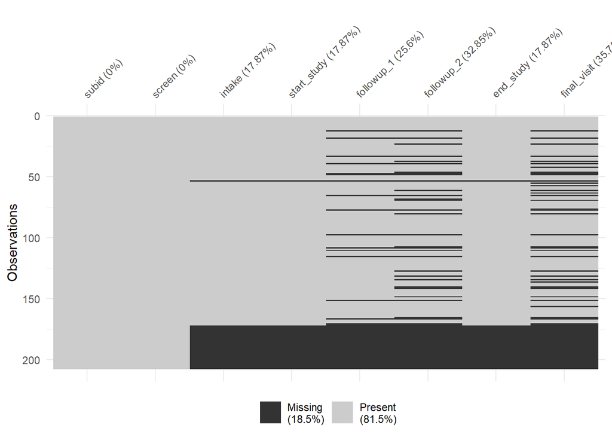

```r
vis_miss(visit_dates)
```

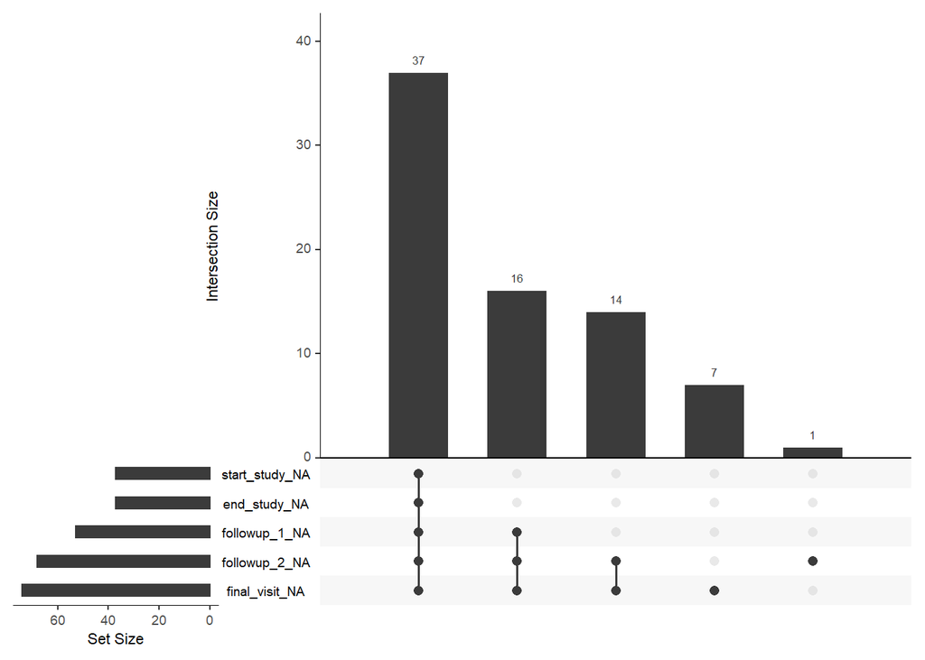

```r
gg_miss_upset(visit_dates)
```

## Write CSV

```r
write_csv(visit_dates, file.path(path_data, "visit_dates.csv")) %>%
  glimpse()
```

```
## Rows: 207
## Columns: 8
## $ subid       <dbl> 1, 2, 3, 5, 6, 7, 9, 10, 11, 15, 16, 17, 18, 19, 20, 21...
## $ screen      <chr> "2017-02-15", "2017-02-17", "2017-03-07", "2017-05-31",...
## $ intake      <chr> "2017-03-01", "2017-03-23", "2017-03-21", "2017-06-19",...
## $ start_study <chr> "2017-03-02", "2017-03-24", "2017-03-22", "2017-06-20",...
## $ followup_1  <chr> "2017-03-31", "2017-04-21", "2017-04-26", "2017-07-19",...
## $ followup_2  <chr> "2017-05-01", "2017-05-22", "2017-05-24", "2017-08-21",...
## $ end_study   <chr> "2017-05-31", "2017-06-16", "2017-06-20", "2017-09-18",...
## $ final_visit <chr> "2017-06-05", "2017-06-16", "2017-06-21", "2017-09-22",...
```